# Evaluation Physicochemical Drivers of River Flow Using Weighted Regression

Kenshi King

2025-11-28

## Data Set Credits

Author: Daniel Fedorov

Source: Kaggle

```r
#imports
library(tidyverse) #data wrangling
```

```r
library(ggplot2) #visualizations
library(ggcorrplot) #correlation plots
library(lmtest) #Breusch-Pagan test
library(car) #vif, Box-Cox test, components + residuals plot
library(caTools) #train/test split
library(broom) #coefficient plot
```

```r
list.files("figures")
```

```
## [1] "coefficient_plot.png"           "correlation_heatmap_after.png"
## [3] "correlation_heatmap_before.png" "predicted_vs_actual.png"
## [5] "qq_plot.png"                    "residuals_vs_fitted.png"
## [7] "water_speed_distribution.png"
```

## Key

This key contains relevant variables to our analysis and their units of measurement:

1. Average Water Speed (cm/s)

2. Average Water Direction (degrees)

3. Chlorophyll (ug/L)

4. Temperature (°C)

5. Dissolved Oxygen (mg/L)

6. Dissolved Oxygen (% Saturation)

7. pH

8. Salinity (ppm)

9. Specific Conductance (mS/cm)

10. Turbidity (Formazin Nephelometric Units (FNU))

## Introduction

This project examines a dataset provided by the Queensland Government Open Data Portal containing measurements of water physicochemcical parameters of the Brisbane River in Australia (Fedorov). The dataset includes timestamps, record numbers, and various characteristics of the river during a given instance. Using this data, we aim to test whether or not the average water speed is influenced by these river characteristics. Understanding water speed is crucial because it affects numerous things: river habitats and aquatic biodiversity, agriculture, hydroelectric power generation, erosion, flood risk management, and many others. Monitoring these speeds is tantamount to ensuring risk management and environmental protection (Fain).

```r
#Loading in our dataset
df <- read_csv('brisbane_water_quality.csv')
head(df)
```

```
## # A tibble: 6 × 20
##   Timestamp           `Record number` `Average Water Speed`
##   <dttm>                        <dbl>                 <dbl>
## 1 2023-08-04 23:00:00            1468                  4.83
## 2 2023-08-04 23:30:00            1469                  2.54
## 3 2023-08-04 23:00:00            1470                  1.26
## 4 2023-08-04 23:30:00            1471                  0.76
## 5 2023-08-04 23:00:00            1472                  3.40
## 6 2023-08-04 23:00:00            1473                  1.60
## # ℹ 17 more variables: `Average Water Direction` <dbl>, Chlorophyll <dbl>,
## #   `Chlorophyll [quality]` <dbl>, Temperature <dbl>,
## #   `Temperature [quality]` <dbl>, `Dissolved Oxygen` <dbl>,
## #   `Dissolved Oxygen [quality]` <dbl>, `Dissolved Oxygen (%Saturation)` <dbl>,
## #   `Dissolved Oxygen (%Saturation) [quality]` <dbl>, pH <dbl>,
## #   `pH [quality]` <dbl>, Salinity <dbl>, `Salinity [quality]` <dbl>,
## #   `Specific Conductance` <dbl>, `Specific Conductance [quality]` <dbl>, …
```

## Section 1: Descriptive Statistics and Checking Assumptions

We begin our analysis by first examining some characteristics of the dataset. Descriptive statistics are helpful in arming us with useful data points as well as allowing us to detect potential outliers whether that be highly correlated variables or null values (NA). We will ignore columns Timestamp column as it may over complicate our analysis and the various [quality] columns due to their long stretch of null values.

```r
water <- df %>%
  select(`Average Water Speed`, `Average Water Direction`, Chlorophyll, Temperature, `Dissolved Oxygen`, pH, Salinity, `Specific Conductance`, Turbidity)
water
```

```
## # A tibble: 30,894 × 9
##    `Average Water Speed` `Average Water Direction` Chlorophyll Temperature
##                    <dbl>                     <dbl>       <dbl>       <dbl>
##  1                  4.83                      73.5        1.62        20.0
##  2                  2.54                     106.         1.96        20.0
##  3                  1.26                     157.         1.62        20.0
##  4                  0.76                     282.         1.76        20.0
##  5                  3.40                     245.         1.64        20.0
##  6                  1.60                     100.         1.94        19.8
##  7                  6.62                     142.         2.10        19.8
##  8                  9.14                      52.0        1.44        19.8
##  9                  2.98                      93.1        1.43        19.8
## 10                  9.85                      53.1        1.50        19.8
## # ℹ 30,884 more rows
## # ℹ 5 more variables: `Dissolved Oxygen` <dbl>, pH <dbl>, Salinity <dbl>,
## #   `Specific Conductance` <dbl>, Turbidity <dbl>
```

This dataset contains over 30,000 observations of the Brisbane River, capturing variation in the water’s physicochemical parameters across 30-minute intervals. Before cleaning, many variables contained a substantial amount of missing values, most notably temperature (5164 missing), dissolved oxygen (4300 missing), salinity (3958 missing), and turbidity (2000 missing). After removing these rows to ensure we only have complete observations, the dataset retained the majority of its observations while dropping potential inconsistencies. (Potentially revise to fill the missing with avg or median values, depends on the gap lengths*)

```r
clean_water <- na.omit(water)
```

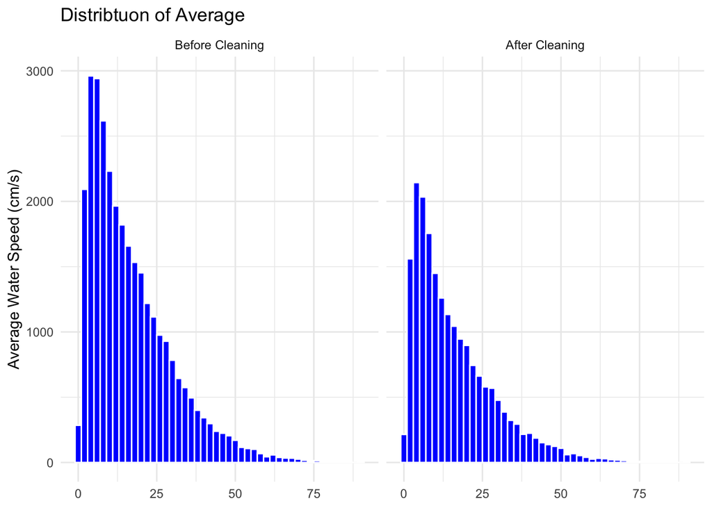

```r
#Uncleaned and cleaned placeholders
water_plot <- water %>%
  select(`Average Water Speed`) %>%
           mutate(stage = "Before Cleaning")
clean_water_plot <- clean_water %>%
  select(`Average Water Speed`) %>%
  mutate(stage = "After Cleaning")

combined <- bind_rows(water_plot, clean_water_plot)

combined$stage <- factor(combined$stage, levels = c("Before Cleaning", "After Cleaning"))

ggplot(combined, aes(x = `Average Water Speed`)) +
  geom_histogram(binwidth=2, fill="blue", color="white") +
  facet_wrap(~stage) +
  labs(title = "Distribtuon of Average",
       x = NULL,
       y = "Average Water Speed (cm/s)") +
  theme_minimal() +
  theme(legend.position = "none")
```

```r
ggsave("figures/water_speed_distribution.png",
       plot = last_plot(),  # or replace with your saved plot object, e.g. speed_plot
       width = 8, height = 5, dpi = 300)
```

Comparing the summary statistics before and after cleaning the data, some key trends slightly shifted, reflecting the removal of those null/extreme values. For instance, the mean average water speed decreased from ~16.80 to ~16.01, and the median from ~13.39 to ~12.33; the range remained wide, indicating some persistent extreme values. With regards to the other average water direction and the physicochemical parameters, they also exhibited minor changes. (Weighted regression will allow us to skip z-score scaling)

Overall, the removal of these missing values slightly adjusted the descriptive statistics, retaining variability and the general patterns of the dataset. This version provides us with a more reliable starting point for further analysis.

```r
summary(water)
```

```
##  Average Water Speed Average Water Direction  Chlorophyll      Temperature
##  Min.   : 0.000      Min.   :  0.00          Min.   : 0.100   Min.   :17.00
##  1st Qu.: 6.594      1st Qu.: 86.31          1st Qu.: 1.451   1st Qu.:21.29
##  Median :13.390      Median :176.33          Median : 2.371   Median :25.25
##  Mean   :16.799      Mean   :177.54          Mean   : 2.782   Mean   :24.42
##  3rd Qu.:23.600      3rd Qu.:267.87          3rd Qu.: 3.650   3rd Qu.:27.25
##  Max.   :89.912      Max.   :359.99          Max.   :43.301   Max.   :32.06
##  NA's   :20          NA's   :1               NA's   :585      NA's   :5164
##  Dissolved Oxygen       pH           Salinity      Specific Conductance
##  Min.   :3.030    Min.   :7.309   Min.   : 0.057   Min.   : 0.021
##  1st Qu.:6.387    1st Qu.:7.980   1st Qu.:29.151   1st Qu.:45.046
##  Median :6.814    Median :8.073   Median :30.604   Median :47.420
##  Mean   :6.815    Mean   :8.063   Mean   :31.003   Mean   :47.927
##  3rd Qu.:7.254    3rd Qu.:8.140   3rd Qu.:33.918   3rd Qu.:53.361
##  Max.   :9.260    Max.   :8.255   Max.   :36.000   Max.   :54.996
##  NA's   :4300     NA's   :1084    NA's   :3958     NA's   :1367
##    Turbidity
##  Min.   : 0.335
##  1st Qu.: 2.354
##  Median : 3.093
##  Mean   : 3.942
##  3rd Qu.: 4.005
##  Max.   :49.869
##  NA's   :2000
```

```r
summary(clean_water)
```

```
##  Average Water Speed Average Water Direction  Chlorophyll      Temperature
##  Min.   : 0.016      Min.   :  0.02          Min.   : 0.106   Min.   :17.00
##  1st Qu.: 6.031      1st Qu.: 85.06          1st Qu.: 1.570   1st Qu.:20.62
##  Median :12.326      Median :170.99          Median : 2.428   Median :24.66
##  Mean   :16.007      Mean   :175.51          Mean   : 2.808   Mean   :24.01
##  3rd Qu.:22.546      3rd Qu.:266.01          3rd Qu.: 3.575   3rd Qu.:27.20
##  Max.   :89.912      Max.   :359.99          Max.   :43.301   Max.   :32.06
##  Dissolved Oxygen       pH           Salinity      Specific Conductance
##  Min.   :3.030    Min.   :7.309   Min.   : 0.158   Min.   : 0.334
##  1st Qu.:6.385    1st Qu.:8.048   1st Qu.:28.860   1st Qu.:44.621
##  Median :6.825    Median :8.106   Median :29.843   Median :46.101
##  Mean   :6.806    Mean   :8.093   Mean   :30.307   Mean   :46.629
##  3rd Qu.:7.249    3rd Qu.:8.154   3rd Qu.:31.813   3rd Qu.:48.876
##  Max.   :9.260    Max.   :8.253   Max.   :36.000   Max.   :54.506
##    Turbidity
##  Min.   : 0.365
##  1st Qu.: 2.582
##  Median : 3.198
##  Mean   : 4.451
##  3rd Qu.: 4.168
##  Max.   :49.869
```

## Section 2: Model Preparation and Fitting

Here, we are interested in seeing if there are any variables with relationships that are a bit too strong. Highly correlated pairs can lead to multicollinearity, which can inflate standard errors and lower our model’s estimates and predicting power. On a 0 to 1 scale, a common “rule-of-thumb” threshold is usually <0.7, with any pairs going past this potentially indicating multicollinearity. As shown below, Salinity and Specific Conductance are extremely correlated (~0.999), which makes sense logically as conductance of water is highly dependent on its salt contents so if a river is measured to have a high amount of salinity, its specific conductance will also be high. To address this, we will remove Specific Conductance from our model, retaining Salinity as its presenter.

```r
cor(clean_water[,-c(1,9)])
```

```
##                         Average Water Direction  Chlorophyll Temperature
## Average Water Direction             1.000000000 -0.005431517 -0.06152078
## Chlorophyll                        -0.005431517  1.000000000  0.25564913
## Temperature                        -0.061520779  0.255649128  1.00000000
## Dissolved Oxygen                   -0.016341960  0.214485051 -0.42673370
## pH                                  0.054432136 -0.115725922 -0.58335925
## Salinity                           -0.016974558 -0.230532217 -0.12532087
## Specific Conductance               -0.017439909 -0.230784434 -0.10682186
##                         Dissolved Oxygen          pH    Salinity
## Average Water Direction      -0.01634196  0.05443214 -0.01697456
## Chlorophyll                   0.21448505 -0.11572592 -0.23053222
## Temperature                  -0.42673370 -0.58335925 -0.12532087
## Dissolved Oxygen              1.00000000  0.42070850 -0.12880685
## pH                            0.42070850  1.00000000  0.03716563
## Salinity                     -0.12880685  0.03716563  1.00000000
## Specific Conductance         -0.14158506  0.03458012  0.99953083
##                         Specific Conductance
## Average Water Direction          -0.01743991
## Chlorophyll                      -0.23078443
## Temperature                      -0.10682186
## Dissolved Oxygen                 -0.14158506
## pH                                0.03458012
## Salinity                          0.99953083
## Specific Conductance              1.00000000
```

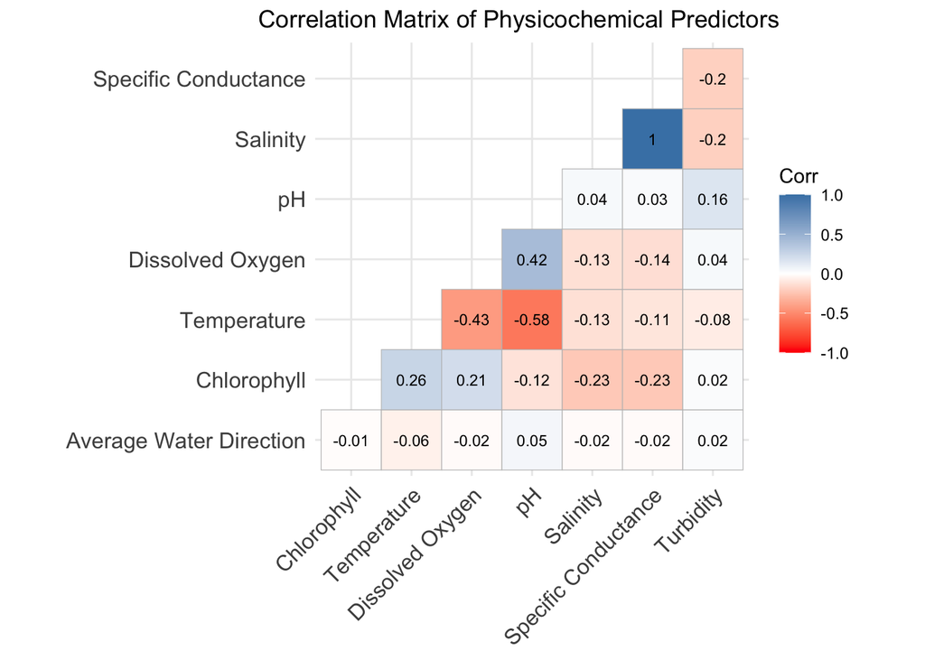

```r
predictors <- clean_water %>%
  select(`Average Water Direction`, Chlorophyll, Temperature, `Dissolved Oxygen`, pH, Salinity, `Specific Conductance`, Turbidity)
corr_matrix <- cor(predictors)

corr_plot <- ggcorrplot(corr_matrix, method = "square",
           type = "lower",
           lab = TRUE,
           lab_size = 3,
           colors = c("red", "white", "steelblue"),
           title = "Correlation Matrix of Physicochemical Predictors",
           ggtheme = theme_minimal()) +
  theme(axis.text.x = element_text(angle=45, hjust=1)) +
  theme(plot.title = element_text(hjust = 0.65))
corr_plot
```

```r
ggsave("figures/correlation_heatmap_before.png", plot = corr_plot, width = 7, height = 6, dpi = 300)
```

After we removed Specific Conductance, no pair of variables exceeded the 0.7 threshold anymore.

```r
cor(clean_water[,c(1,8)])
```

```
##                      Average Water Speed Specific Conductance
## Average Water Speed            1.0000000           -0.2196674
## Specific Conductance          -0.2196674            1.0000000
```

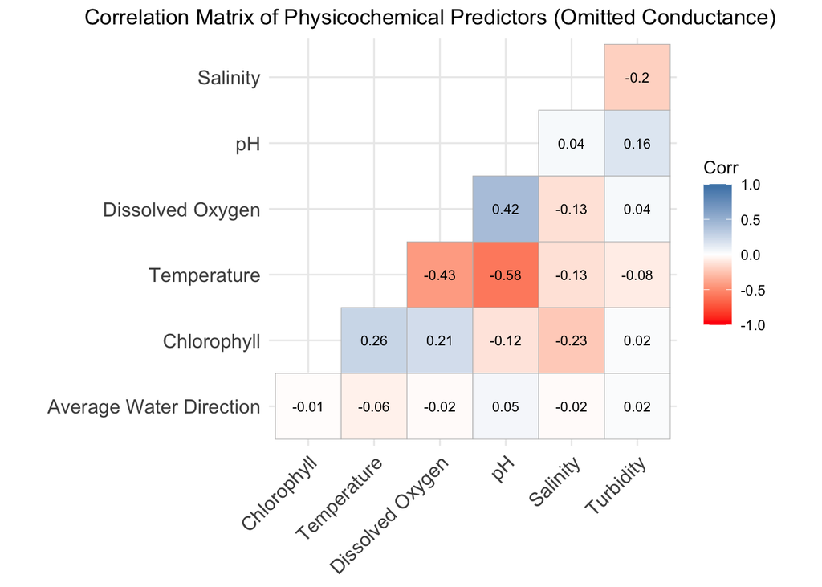

```r
predictors_cleaned <- clean_water %>%
  select(`Average Water Direction`, Chlorophyll, Temperature, `Dissolved Oxygen`, pH, Salinity, Turbidity)
corr_matrix <- cor(predictors_cleaned)

corr_plot <- ggcorrplot(corr_matrix, method = "square",
           type = "lower",
           lab = TRUE,
           lab_size = 3,
           colors = c("red", "white", "steelblue"),
           title = "Correlation Matrix of Physicochemical Predictors (Omitted Conductance)",
           ggtheme = theme_minimal()) +
  theme(axis.text.x = element_text(angle=45, hjust=1)) +
  theme(plot.title = element_text(hjust = 0.65))
corr_plot
```

```r
ggsave("figures/correlation_heatmap_after.png",
       plot = corr_plot,
       width = 7, height = 6, dpi = 300)
```

We create a multiple linear regression model with Average Water Speed being our response variable and the remaining variables (Average Water Direction, Chlorophyll, Temperature, Dissolved Oxygen, pH, Salinity, Turbidity) as our predictors. We will approach this using manual selection, later using step-wise selection to assess if they align.

Looking at the output, we notice that the p-values for Average Water Direction (0.0971) and Temperature (p = 0.5361) exceeds the 0.05 significance threshold, indicating that they may not significantly affect/predict average water direction; we will consider removing temperature first and refitting.

```r
model <- lm(`Average Water Speed` ~ `Average Water Direction` + Chlorophyll+Temperature+`Dissolved Oxygen`+pH+Salinity+Turbidity, data=clean_water)
summary(model)
```

```
##
## Call:
## lm(formula = `Average Water Speed` ~ `Average Water Direction` +
##     Chlorophyll + Temperature + `Dissolved Oxygen` + pH + Salinity +
##     Turbidity, data = clean_water)
##
## Residuals:
##     Min      1Q  Median      3Q     Max
## -29.369  -7.945  -2.945   5.027  80.617
##
## Coefficients:
##                             Estimate Std. Error t value Pr(>|t|)
## (Intercept)               -2.623e+02  1.112e+01 -23.585  < 2e-16 ***
## `Average Water Direction` -1.374e-03  8.280e-04  -1.659   0.0971 .
## Chlorophyll               -2.554e-01  5.364e-02  -4.761 1.94e-06 ***
## Temperature                1.913e-02  3.092e-02   0.619   0.5361
## `Dissolved Oxygen`        -4.556e+00  1.675e-01 -27.200  < 2e-16 ***
## pH                         4.166e+01  1.353e+00  30.793  < 2e-16 ***
## Salinity                  -9.398e-01  2.617e-02 -35.915  < 2e-16 ***
## Turbidity                  2.505e-01  1.891e-02  13.248  < 2e-16 ***
## ---
## Signif. codes:  0 '***' 0.001 '**' 0.01 '*' 0.05 '.' 0.1 ' ' 1
##
## Residual standard error: 12.08 on 20020 degrees of freedom
## Multiple R-squared:  0.1368, Adjusted R-squared:  0.1365
## F-statistic: 453.4 on 7 and 20020 DF,  p-value: < 2.2e-16
```

Upon refitting, Average Water Direction’s p-value (0.0893) still exceeds the 0.05 threshold so we will remove it and refit once more.

```r
model2 <- lm(`Average Water Speed` ~ `Average Water Direction` + Chlorophyll+`Dissolved Oxygen`+pH+Salinity+Turbidity, data=clean_water)
summary(model2)
```

```
##
## Call:
## lm(formula = `Average Water Speed` ~ `Average Water Direction` +
##     Chlorophyll + `Dissolved Oxygen` + pH + Salinity + Turbidity,
##     data = clean_water)
##
## Residuals:
##     Min      1Q  Median      3Q     Max
## -29.445  -7.948  -2.949   5.042  80.596
##
## Coefficients:
##                             Estimate Std. Error t value Pr(>|t|)
## (Intercept)               -2.586e+02  9.401e+00 -27.505  < 2e-16 ***
## `Average Water Direction` -1.404e-03  8.265e-04  -1.699   0.0893 .
## Chlorophyll               -2.452e-01  5.104e-02  -4.804 1.57e-06 ***
## `Dissolved Oxygen`        -4.593e+00  1.567e-01 -29.302  < 2e-16 ***
## pH                         4.130e+01  1.220e+00  33.844  < 2e-16 ***
## Salinity                  -9.419e-01  2.596e-02 -36.288  < 2e-16 ***
## Turbidity                  2.501e-01  1.890e-02  13.235  < 2e-16 ***
## ---
## Signif. codes:  0 '***' 0.001 '**' 0.01 '*' 0.05 '.' 0.1 ' ' 1
##
## Residual standard error: 12.08 on 20021 degrees of freedom
## Multiple R-squared:  0.1368, Adjusted R-squared:  0.1366
## F-statistic: 528.9 on 6 and 20021 DF,  p-value: < 2.2e-16
```

The tentative final model includes Chlorophyll, Dissolved Oxygen, pH, Salinity, and Turbidity. Temperature and Average Water Direction were excluded due to lack of significance. When using stepwise selection using Bayesian Information Criterion (BIC) penalty (since it scales with sample size), it resulted in the same model, indicating that this model provides a balance between goodness of fit and model complexity.

```r
full_model <- lm(`Average Water Speed`~Chlorophyll+`Dissolved Oxygen`+pH+Salinity+Turbidity, data=clean_water)
summary(full_model)
```

```
##
## Call:
## lm(formula = `Average Water Speed` ~ Chlorophyll + `Dissolved Oxygen` +
##     pH + Salinity + Turbidity, data = clean_water)
##
## Residuals:
##     Min      1Q  Median      3Q     Max
## -29.250  -7.950  -2.932   5.048  80.494
##
## Coefficients:
##                      Estimate Std. Error t value Pr(>|t|)
## (Intercept)        -257.81158    9.39072 -27.454  < 2e-16 ***
## Chlorophyll          -0.24599    0.05104  -4.819 1.45e-06 ***
## `Dissolved Oxygen`   -4.58006    0.15657 -29.253  < 2e-16 ***
## pH                   41.15499    1.21743  33.805  < 2e-16 ***
## Salinity             -0.94092    0.02595 -36.258  < 2e-16 ***
## Turbidity             0.24983    0.01890  13.221  < 2e-16 ***
## ---
## Signif. codes:  0 '***' 0.001 '**' 0.01 '*' 0.05 '.' 0.1 ' ' 1
##
## Residual standard error: 12.08 on 20022 degrees of freedom
## Multiple R-squared:  0.1367, Adjusted R-squared:  0.1365
## F-statistic: 634.1 on 5 and 20022 DF,  p-value: < 2.2e-16
```

```r
step(model, direction="both", k=log(20028))
```

```
## Start:  AIC=99859.07
## `Average Water Speed` ~ `Average Water Direction` + Chlorophyll +
##     Temperature + `Dissolved Oxygen` + pH + Salinity + Turbidity
##
##                             Df Sum of Sq     RSS    AIC
## - Temperature                1        56 2919498  99850
## - `Average Water Direction`  1       402 2919844  99852
## <none>                                   2919443  99859
## - Chlorophyll                1      3306 2922748  99872
## - Turbidity                  1     25596 2945038 100024
## - `Dissolved Oxygen`         1    107891 3027334 100576
## - pH                         1    138277 3057720 100776
## - Salinity                   1    188098 3107540 101100
##
## Step:  AIC=99849.55
## `Average Water Speed` ~ `Average Water Direction` + Chlorophyll +
##     `Dissolved Oxygen` + pH + Salinity + Turbidity
##
##                             Df Sum of Sq     RSS    AIC
## - `Average Water Direction`  1       421 2919920  99843
## <none>                                   2919498  99850
## + Temperature                1        56 2919443  99859
## - Chlorophyll                1      3365 2922863  99863
## - Turbidity                  1     25541 2945040 100014
## - `Dissolved Oxygen`         1    125206 3044704 100681
## - pH                         1    167025 3086523 100954
## - Salinity                   1    192019 3111518 101115
##
## Step:  AIC=99842.53
## `Average Water Speed` ~ Chlorophyll + `Dissolved Oxygen` + pH +
##     Salinity + Turbidity
##
##                             Df Sum of Sq     RSS    AIC
## <none>                                   2919920  99843
## + `Average Water Direction`  1       421 2919498  99850
## + Temperature                1        75 2919844  99852
## - Chlorophyll                1      3387 2923307  99856
## - Turbidity                  1     25490 2945410 100007
## - `Dissolved Oxygen`         1    124800 3044719 100671
## - pH                         1    166655 3086574 100944
## - Salinity                   1    191719 3111638 101106
```

```
##
## Call:
## lm(formula = `Average Water Speed` ~ Chlorophyll + `Dissolved Oxygen` +
##     pH + Salinity + Turbidity, data = clean_water)
##
## Coefficients:
##        (Intercept)         Chlorophyll  `Dissolved Oxygen`                  pH
##          -257.8116             -0.2460             -4.5801             41.1550
##           Salinity           Turbidity
##            -0.9409              0.2498
```

Furthermore, the Variance Inflation Factor (VIF) values for all predictors are well below the common threshold of 5, indicating that multicollinearity is not a concern of this model.

```r
vif(full_model)
```

```
##        Chlorophyll `Dissolved Oxygen`                 pH           Salinity
##           1.150727           1.347967           1.330623           1.117600
##          Turbidity
##           1.077958
```

## Section 3: Diagnostics

```r
resid_df <- data.frame(fitted = full_model$fitted.values,
                       residuals = full_model$residuals)

resid_plot <- ggplot(resid_df, aes(x=fitted, y=residuals)) +
  geom_point(alpha=0.4, color="steelblue") +
  geom_hline(yintercept=0, color="firebrick", linetype="dashed") +
  labs(title="Residuals vs. Fitted Values",
       x="Fitted Values",
       y="Residuals") +
  theme_minimal() +
  theme(plot.title = element_text(hjust=0.5))
full_model$residuals
```

[output not shown]

[output cut: 7957 more lines]

[output not shown]

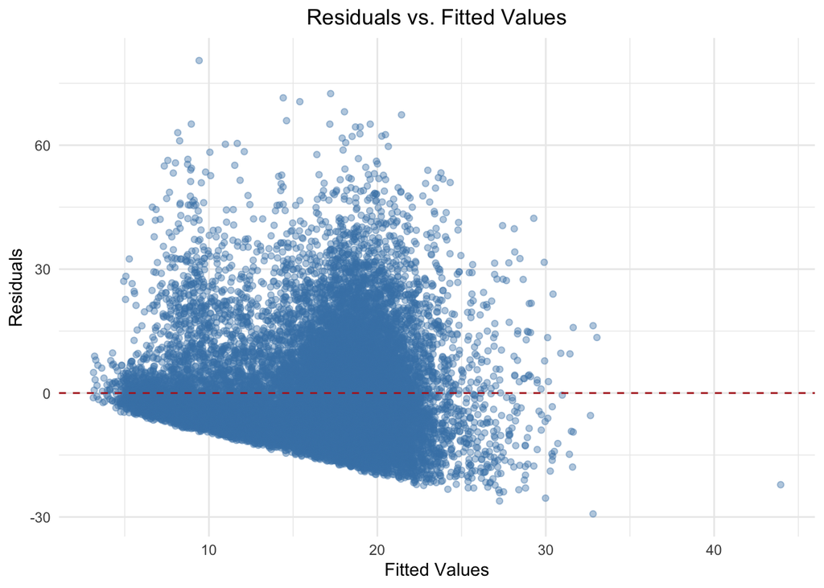

```r
resid_plot
```

```r
ggsave("figures/residuals_vs_fitted.png",
       plot = resid_plot,
       width = 7, height = 6, dpi = 300)
```

Our Q-Q plot shows a slightly exponential trend beginning to form about x-axis = 1, causing some deviation in our linearity assumption. Our Component + Residuals (crPlots) also agree with this deviation of linearity, indicating that some transformation may be necessary.

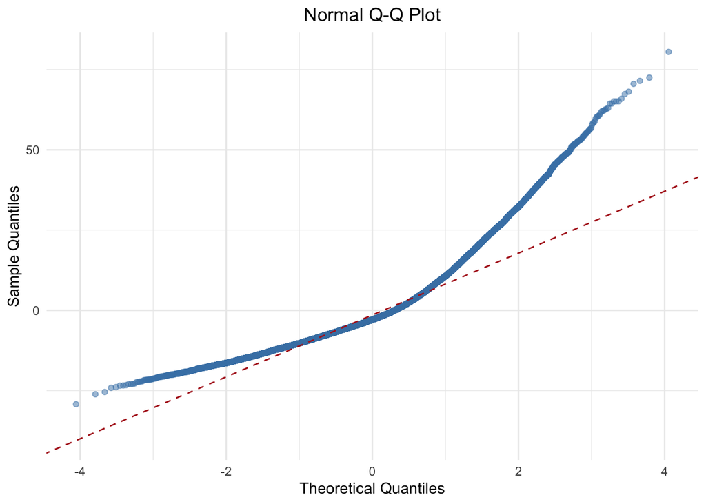

```r
qq_plot <- ggplot(resid_df, aes(sample=residuals)) +
    stat_qq(color="steelblue", alpha=0.5) +
    stat_qq_line(color="firebrick", linetype="dashed") +
    labs(title="Normal Q-Q Plot",
         x="Theoretical Quantiles",
         y="Sample Quantiles") +
    theme_minimal() +
    theme(plot.title = element_text(hjust=0.5))
qq_plot
```

```r
ggsave("figures/qq_plot.png",
       plot = qq_plot,
       width = 7, height = 6, dpi = 300)
```

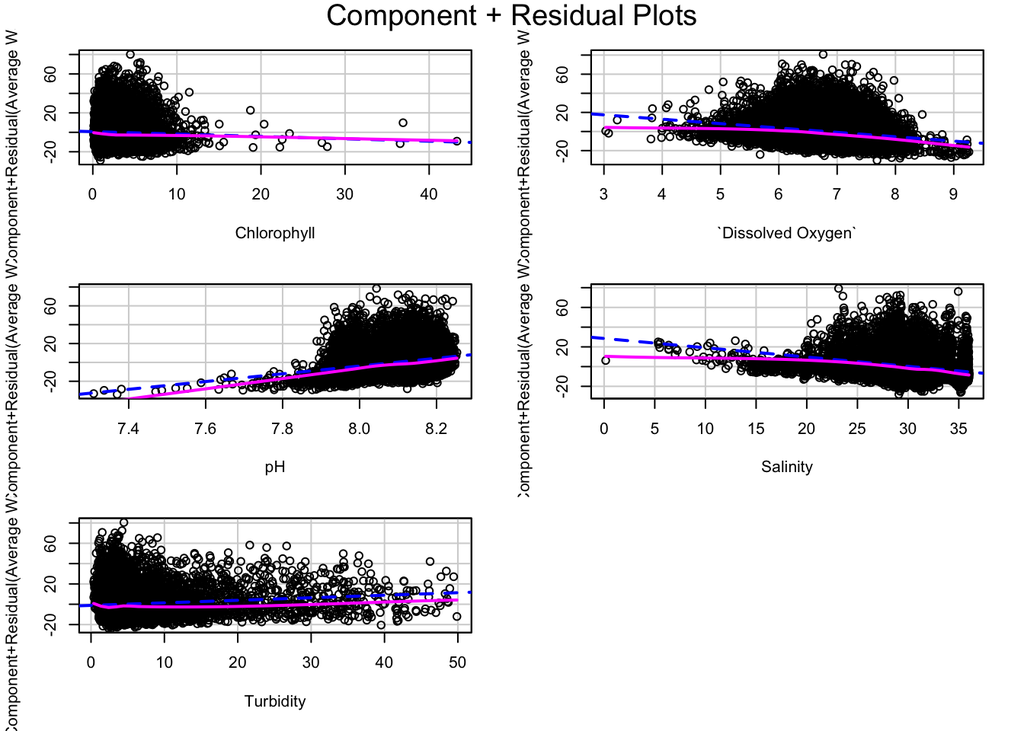

```r
crPlots(full_model)
```

```r
cook <- cooks.distance(full_model)
max(cook)
```

```
## [1] 0.008554348
```

```r
box_cox <- powerTransform(`Average Water Speed` ~Chlorophyll+`Dissolved Oxygen` +pH+Salinity+Turbidity, data=clean_water)
summary(box_cox)
```

```
## bcPower Transformation to Normality
##    Est Power Rounded Pwr Wald Lwr Bnd Wald Upr Bnd
## Y1    0.2065        0.21       0.1937       0.2192
##
## Likelihood ratio test that transformation parameter is equal to 0
##  (log transformation)
##                            LRT df       pval
## LR test, lambda = (0) 1089.636  1 < 2.22e-16
##
## Likelihood ratio test that no transformation is needed
##                            LRT df       pval
## LR test, lambda = (1) 11736.15  1 < 2.22e-16
```

To address the issue of heteroscedasticity, we apply the Weighted Least Squares (WLS) to give less influence to observations with higher variance in residuals, resulting in more reliable coefficient estimates and improving the homoscedasticity assumption.

```r
ols <- lm(`Average Water Speed` ~Chlorophyll+`Dissolved Oxygen` +pH+Salinity+Turbidity, data=clean_water)
residual_sq <- resid(ols)^2
var_model <- lm(residual_sq~fitted(ols))
pred_var <- predict(var_model)
weight <- (1/pred_var)
wls <- lm(`Average Water Speed` ~Chlorophyll+`Dissolved Oxygen` +pH+Salinity+Turbidity, data=clean_water, weights=weight)
summary(wls)
```

```
##
## Call:
## lm(formula = `Average Water Speed` ~ Chlorophyll + `Dissolved Oxygen` +
##     pH + Salinity + Turbidity, data = clean_water, weights = weight)
##
## Weighted Residuals:
##     Min      1Q  Median      3Q     Max
## -1.7642 -0.6869 -0.2600  0.4204  8.2802
##
## Coefficients:
##                      Estimate Std. Error t value Pr(>|t|)
## (Intercept)        -227.51740    8.79744 -25.862  < 2e-16 ***
## Chlorophyll          -0.14242    0.04801  -2.967  0.00301 **
## `Dissolved Oxygen`   -4.88709    0.14930 -32.733  < 2e-16 ***
## pH                   37.72614    1.13579  33.216  < 2e-16 ***
## Salinity             -0.96587    0.02375 -40.666  < 2e-16 ***
## Turbidity             0.25246    0.02245  11.246  < 2e-16 ***
## ---
## Signif. codes:  0 '***' 0.001 '**' 0.01 '*' 0.05 '.' 0.1 ' ' 1
##
## Residual standard error: 0.9994 on 20022 degrees of freedom
## Multiple R-squared:  0.1653, Adjusted R-squared:  0.1651
## F-statistic: 793.2 on 5 and 20022 DF,  p-value: < 2.2e-16
```

Since applying the WLS approach, the BP test yielded a higher p-value (0.000204), indicating that while some heteroscedasticity remains, the variance of residuals has improved compared to the original model.

```r
bptest(wls)
```

```
##
##  studentized Breusch-Pagan test
##
## data:  wls
## BP = 24.141, df = 5, p-value = 0.000204
```

```r
outlierTest(wls)
```

```
##       rstudent unadjusted p-value Bonferroni p
## 3340  8.299967         1.1067e-16   2.2165e-12
## 3805  6.858105         7.1815e-12   1.4383e-07
## 4104  6.754240         1.4753e-11   2.9547e-07
## 3806  6.611072         3.9116e-11   7.8342e-07
## 3385  6.328517         2.5278e-10   5.0627e-06
## 3524  6.199580         5.7721e-10   1.1560e-05
## 3746  6.187462         6.2327e-10   1.2483e-05
## 3938  6.093128         1.1275e-09   2.2581e-05
## 5051  5.978047         2.2966e-09   4.5996e-05
## 11844 5.946008         2.7932e-09   5.5942e-05
```

```r
outlier <- c(1,2,3340,3805,4104,3385,3524,3746,3938,5051,11844)
clean_water[outlier,]
```

```
## # A tibble: 11 × 9
##    `Average Water Speed` `Average Water Direction` Chlorophyll Temperature
##                    <dbl>                     <dbl>       <dbl>       <dbl>
##  1                  4.83                      73.5        1.62        20.0
##  2                  2.54                     106.         1.96        20.0
##  3                 89.9                      241.         4.46        24.3
##  4                 71.2                      229.         2.49        27.7
##  5                 74.1                      230.         6.39        27.2
##  6                 63.9                       75.2        4.33        24.4
##  7                 62.3                       12.2        2.51        27.5
##  8                 85.9                       32.7        5.33        24.6
##  9                 63.7                      196.         4.54        27.9
## 10                 65.3                       75.1        4.17        31.6
## 11                 85.9                      301.         5.60        24.3
## # ℹ 5 more variables: `Dissolved Oxygen` <dbl>, pH <dbl>, Salinity <dbl>,
## #   `Specific Conductance` <dbl>, Turbidity <dbl>
```

```r
final <- clean_water[!(seq_len(nrow(clean_water)) %in% outlier), ]
final
```

```
## # A tibble: 20,017 × 9
##    `Average Water Speed` `Average Water Direction` Chlorophyll Temperature
##                    <dbl>                     <dbl>       <dbl>       <dbl>
##  1                 1.26                      157.         1.62        20.0
##  2                 0.76                      282.         1.76        20.0
##  3                 3.40                      245.         1.64        20.0
##  4                 1.60                      100.         1.94        19.8
##  5                 6.62                      142.         2.10        19.8
##  6                 9.14                       52.0        1.44        19.8
##  7                 2.98                       93.1        1.43        19.8
##  8                 9.85                       53.1        1.50        19.8
##  9                 3.37                      318.         1.08        19.7
## 10                 0.283                     324.         1.00        19.7
## # ℹ 20,007 more rows
## # ℹ 5 more variables: `Dissolved Oxygen` <dbl>, pH <dbl>, Salinity <dbl>,
## #   `Specific Conductance` <dbl>, Turbidity <dbl>
```

```r
final_ols <- lm(`Average Water Speed` ~Chlorophyll+`Dissolved Oxygen` +pH+Salinity+Turbidity, data=final)
residual_sq <- resid(final_ols)^2
var_model<-lm(residual_sq~fitted(final_ols))
pred_var<- predict(var_model)
final_weight <- (1/pred_var)
```

```r
final_wls <- lm(`Average Water Speed` ~Chlorophyll+`Dissolved Oxygen` +pH+Salinity+Turbidity, data=final, weights=final_weight)
bptest(final_wls)
```

```
##
##  studentized Breusch-Pagan test
##
## data:  final_wls
## BP = 25.424, df = 5, p-value = 0.0001154
```

## Section 4: Predictive Validation

In order to assess whether or not the model generalizes beyond the data it was fit on, we implement a train/test split approach into a 80% and 20% subset, respectively. The weighted least squares model was refit using only the training data, with weights recalculated with training residuals to avoid overlap with the test set. The fitted model was then used to predict Average Water Speed.

```r
#randomizing seed for reproducibility + 7 is lucky
set.seed(777)

#Split
split <- sample.split(final$`Average Water Speed`, SplitRatio = 0.8)

#Train/Test sets
training_set <- subset(final, split == TRUE)
test_set <- subset(final, split == FALSE)

#Refit WLS on training data only
train_ols <- lm(`Average Water Speed`~Chlorophyll+`Dissolved Oxygen`+pH+Salinity+Turbidity, data=training_set)
train_resid_sq <- resid(train_ols)^2
train_var_model <- lm(train_resid_sq~fitted(train_ols))
train_pred_var <- predict(train_var_model)
train_weight <- 1/train_pred_var
train_wls <- lm(`Average Water Speed`~Chlorophyll+`Dissolved Oxygen`+pH+Salinity+Turbidity, data=training_set, weights=train_weight)
summary(train_wls)
```

```
##
## Call:
## lm(formula = `Average Water Speed` ~ Chlorophyll + `Dissolved Oxygen` +
##     pH + Salinity + Turbidity, data = training_set, weights = train_weight)
##
## Weighted Residuals:
##     Min      1Q  Median      3Q     Max
## -1.7510 -0.6878 -0.2586  0.4196  5.9019
##
## Coefficients:
##                      Estimate Std. Error t value Pr(>|t|)
## (Intercept)        -223.08215    9.91721 -22.494  < 2e-16 ***
## Chlorophyll          -0.15392    0.05190  -2.966  0.00302 **
## `Dissolved Oxygen`   -4.81256    0.16571 -29.042  < 2e-16 ***
## pH                   37.14997    1.27944  29.036  < 2e-16 ***
## Salinity             -0.97439    0.02646 -36.830  < 2e-16 ***
## Turbidity             0.24187    0.02500   9.675  < 2e-16 ***
## ---
## Signif. codes:  0 '***' 0.001 '**' 0.01 '*' 0.05 '.' 0.1 ' ' 1
##
## Residual standard error: 0.999 on 16007 degrees of freedom
## Multiple R-squared:  0.1669, Adjusted R-squared:  0.1666
## F-statistic: 641.2 on 5 and 16007 DF,  p-value: < 2.2e-16
```

```r
#Test
test_pred <- predict(train_wls, newdata=test_set)

#Results
test_actual <- test_set$`Average Water Speed`
rmse <- sqrt(mean((test_pred-test_actual)^2))
mae <- mean(abs(test_pred-test_actual))

rmse
```

```
## [1] 12.02399
```

```r
mae
```

```
## [1] 8.982029
```

The resulting test set RMSE was 12.02 cm/s and MAE was 8.98 cm/s. The RMSE aligns closely with the residual standard error of the original unweighted model (~12.08 cm/s), suggesting that the model’s predictive performance on unseen data is consistent with its in sample fit rather than reflecting overfitting.

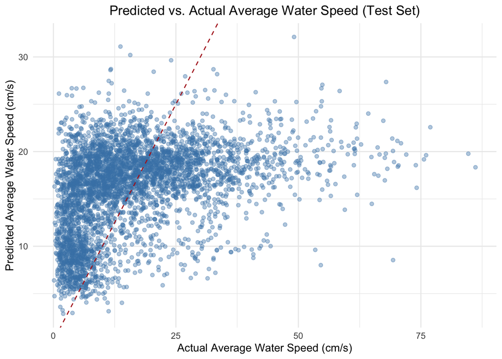

```r
pred_df <- data.frame(actual = test_set$`Average Water Speed`,
                      predicted = test_pred)

pred_plot <- ggplot(pred_df, aes(x=actual, y=predicted)) +
  geom_point(alpha=0.4, color="steelblue") +
  geom_abline(slope=1, intercept=0, color="firebrick", linetype="dashed") +
  labs(title="Predicted vs. Actual Average Water Speed (Test Set)",
       x="Actual Average Water Speed (cm/s)",
       y="Predicted Average Water Speed (cm/s)") +
  theme_minimal() +
  theme(plot.title = element_text(hjust=0.5))
pred_plot
```

```r
ggsave("figures/predicted_vs_actual.png",
       plot = pred_plot,
       width = 7, height = 6, dpi = 300)
```

## Section 5: Analysis

```r
summary(final_wls)
```

```
##
## Call:
## lm(formula = `Average Water Speed` ~ Chlorophyll + `Dissolved Oxygen` +
##     pH + Salinity + Turbidity, data = final, weights = final_weight)
##
## Weighted Residuals:
##     Min      1Q  Median      3Q     Max
## -1.7513 -0.6916 -0.2605  0.4261  6.8128
##
## Coefficients:
##                      Estimate Std. Error t value Pr(>|t|)
## (Intercept)        -226.96076    8.65813 -26.214  < 2e-16 ***
## Chlorophyll          -0.15291    0.04680  -3.268  0.00109 **
## `Dissolved Oxygen`   -4.90784    0.14686 -33.419  < 2e-16 ***
## pH                   37.70197    1.11733  33.743  < 2e-16 ***
## Salinity             -0.97320    0.02334 -41.692  < 2e-16 ***
## Turbidity             0.25338    0.02249  11.264  < 2e-16 ***
## ---
## Signif. codes:  0 '***' 0.001 '**' 0.01 '*' 0.05 '.' 0.1 ' ' 1
##
## Residual standard error: 0.9992 on 20011 degrees of freedom
## Multiple R-squared:  0.1727, Adjusted R-squared:  0.1725
## F-statistic: 835.5 on 5 and 20011 DF,  p-value: < 2.2e-16
```

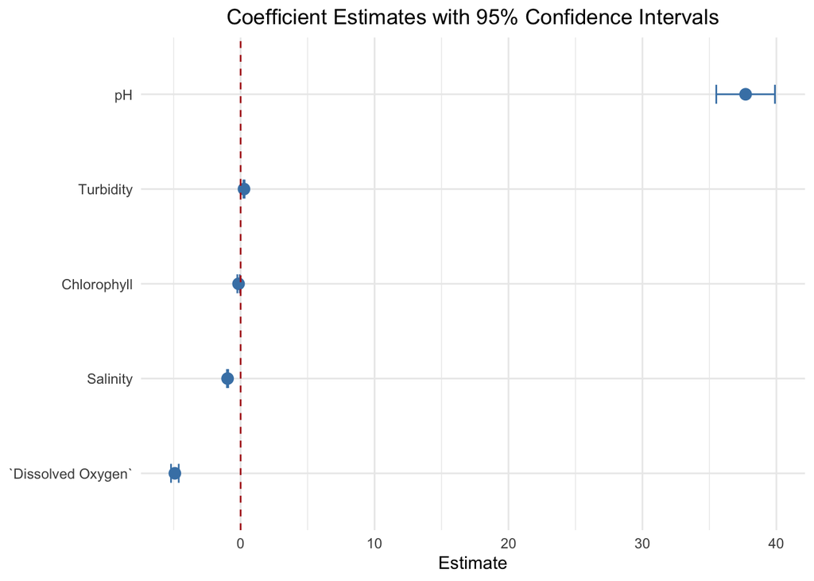

```r
coef_df <- tidy(final_wls, conf.int = TRUE) %>%
  filter(term !="(Intercept)")

coef_plot <- ggplot(coef_df, aes(x = estimate, y = reorder(term, estimate))) +
  geom_point(color = "steelblue", size = 3) +
  geom_errorbar(aes(xmin = conf.low, xmax = conf.high),
                width = 0.2, color = "steelblue", orientation = "y") +
  geom_vline(xintercept = 0, color = "firebrick", linetype = "dashed") +
  labs(title = "Coefficient Estimates with 95% Confidence Intervals",
       x = "Estimate",
       y = NULL) +
  theme_minimal() +
  theme(plot.title = element_text(hjust = 0.5))
coef_plot
```

```r
ggsave("figures/coefficient_plot.png",
       plot = coef_plot,
       width = 7, height = 5, dpi = 300)
```

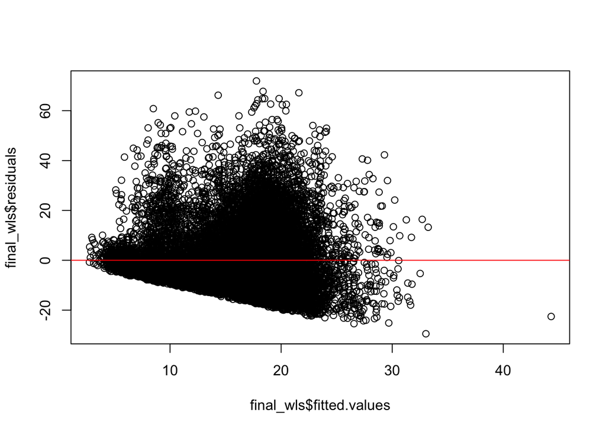

```r
plot(final_wls$fitted.values, final_wls$residuals)
abline(h=0, col="red")
```

## Section 6: Limitations and Future Implementations

Finally, the train/test validation performed did give us confirmation that the data generalizes well with unseen data, but this could be further extended using k-fold cross-validation to give us a greater range of estimates across many partitions to better defend our findings.

## Conclusion

Overall, this model offers a robust and interpretable scheme for understanding river flow, emphasizing that while rivers are inherently dynamic and influenced by a multifaceted range of external factors, careful monitoring of these key parameters can provide valuable insights for environmental management, risk mitigation, and ecological preservation.

## Works Cited

1. Fain, Jeremy. “Understanding Surface Water Speed in Rivers: Why It Matters and How It’s Measured - Blue Water Intelligence (BWI).” *Blue Water Intelligence (BWI)*, 8 Sept. 2025, https://bwi.earth/understanding-surface-water-speed-in-rivers-why-it-matters-and-how-its-measured/.
2. Fedorov, Daniel. “Water Quality Monitoring Dataset.” *Kaggle.Com*, 2024, https://www.kaggle.com/datasets/downshift/water-quality-monitoring-dataset.
3. Less, Diani F. S., et al. “Seasonal and Daily Variation of Hydrodynamic Conditions in the Amazon River Mouth: Influence of Discharge and Tide on Flow Velocity.” *Journal of Coastal Research*, vol. 37, no. 6, Aug. 2021, https://doi.org/10.2112/jcoastres-d-21-00010.1.
4. Trent, Roy, and Scott Brown. *An Overview of Factors Affecting River Stability*. 30 Dec. 1984, https://onlinepubs.trb.org/Onlinepubs/trr/1984/950/950v2-017.pdf.
5. Queensland Government. “Home.” www.data.qld.gov.au, 23 Apr. 2020, [www.data.qld.gov.au/.](https://www.data.qld.gov.au/dataset/brisbane-river-colmslie-site-water-quality-monitoring-buoy/resource/0ec4dacc-8e78-4c2a-aa70-d7865ec098e2)
6. Wickham, Hadley, and Garrett Grolemund. R for Data Science : Import, Tidy, Transform, Visualize, and Model Data. O’reilly, 2017, https://r4ds.had.co.nz/index.html.